# DATA - 413/613 - Homework 3: Functions

Author

Ana Miranda

Published

October 21, 2024

## 1 Description

This repository contains two functions: **“df_attributes.R”** and **“df_plot_by_class.R”**. These functions can be used for analyzing and investigating any given R data frame.

The function **“df_attributes.R”** can be used to extract the characteristics of a data frame. It creates and outputs a new data frame containing the following information extracted from the original input data frame: the variable name(s), variable class(es), variable type(s), number of unique values and number of missing values, for all columns in a data frame.

The function **“df_plot_by_class.R”** may be used to create a set of plots for a specific variable class and for all variables in the data frame with that variable class. It takes as inputs a data frame and the name of the variable class of interest such as character, numeric, double, integer, factor and logical.

The examples below show how to source and use the functions in your code as part of a workflow.

## 2 Examples

To demonstrate the functions, I will use the following R system data frames: **mpg, mtcars and starwars**, as the functions depend on the {tidyverse} R package.

```r
suppressMessages(library(tidyverse))

data(mpg)
glimpse(mpg)
```

```
Rows: 234
Columns: 11
$ manufacturer <chr> "audi", "audi", "audi", "audi", "audi", "audi", "audi", "…
$ model        <chr> "a4", "a4", "a4", "a4", "a4", "a4", "a4", "a4 quattro", "…
$ displ        <dbl> 1.8, 1.8, 2.0, 2.0, 2.8, 2.8, 3.1, 1.8, 1.8, 2.0, 2.0, 2.…
$ year         <int> 1999, 1999, 2008, 2008, 1999, 1999, 2008, 1999, 1999, 200…
$ cyl          <int> 4, 4, 4, 4, 6, 6, 6, 4, 4, 4, 4, 6, 6, 6, 6, 6, 6, 8, 8, …
$ trans        <chr> "auto(l5)", "manual(m5)", "manual(m6)", "auto(av)", "auto…
$ drv          <chr> "f", "f", "f", "f", "f", "f", "f", "4", "4", "4", "4", "4…
$ cty          <int> 18, 21, 20, 21, 16, 18, 18, 18, 16, 20, 19, 15, 17, 17, 1…
$ hwy          <int> 29, 29, 31, 30, 26, 26, 27, 26, 25, 28, 27, 25, 25, 25, 2…
$ fl           <chr> "p", "p", "p", "p", "p", "p", "p", "p", "p", "p", "p", "p…
$ class        <chr> "compact", "compact", "compact", "compact", "compact", "c…
```

```r
data(mtcars)
glimpse(mtcars)
```

```
Rows: 32
Columns: 11
$ mpg  <dbl> 21.0, 21.0, 22.8, 21.4, 18.7, 18.1, 14.3, 24.4, 22.8, 19.2, 17.8,…
$ cyl  <dbl> 6, 6, 4, 6, 8, 6, 8, 4, 4, 6, 6, 8, 8, 8, 8, 8, 8, 4, 4, 4, 4, 8,…
$ disp <dbl> 160.0, 160.0, 108.0, 258.0, 360.0, 225.0, 360.0, 146.7, 140.8, 16…
$ hp   <dbl> 110, 110, 93, 110, 175, 105, 245, 62, 95, 123, 123, 180, 180, 180…
$ drat <dbl> 3.90, 3.90, 3.85, 3.08, 3.15, 2.76, 3.21, 3.69, 3.92, 3.92, 3.92,…
$ wt   <dbl> 2.620, 2.875, 2.320, 3.215, 3.440, 3.460, 3.570, 3.190, 3.150, 3.…
$ qsec <dbl> 16.46, 17.02, 18.61, 19.44, 17.02, 20.22, 15.84, 20.00, 22.90, 18…
$ vs   <dbl> 0, 0, 1, 1, 0, 1, 0, 1, 1, 1, 1, 0, 0, 0, 0, 0, 0, 1, 1, 1, 1, 0,…
$ am   <dbl> 1, 1, 1, 0, 0, 0, 0, 0, 0, 0, 0, 0, 0, 0, 0, 0, 0, 1, 1, 1, 0, 0,…
$ gear <dbl> 4, 4, 4, 3, 3, 3, 3, 4, 4, 4, 4, 3, 3, 3, 3, 3, 3, 4, 4, 4, 3, 3,…
$ carb <dbl> 4, 4, 1, 1, 2, 1, 4, 2, 2, 4, 4, 3, 3, 3, 4, 4, 4, 1, 2, 1, 1, 2,…
```

```r
data(starwars)
glimpse(starwars)
```

```
Rows: 87
Columns: 14
$ name       <chr> "Luke Skywalker", "C-3PO", "R2-D2", "Darth Vader", "Leia Or…
$ height     <int> 172, 167, 96, 202, 150, 178, 165, 97, 183, 182, 188, 180, 2…
$ mass       <dbl> 77.0, 75.0, 32.0, 136.0, 49.0, 120.0, 75.0, 32.0, 84.0, 77.…
$ hair_color <chr> "blond", NA, NA, "none", "brown", "brown, grey", "brown", N…
$ skin_color <chr> "fair", "gold", "white, blue", "white", "light", "light", "…
$ eye_color  <chr> "blue", "yellow", "red", "yellow", "brown", "blue", "blue",…
$ birth_year <dbl> 19.0, 112.0, 33.0, 41.9, 19.0, 52.0, 47.0, NA, 24.0, 57.0, …
$ sex        <chr> "male", "none", "none", "male", "female", "male", "female",…
$ gender     <chr> "masculine", "masculine", "masculine", "masculine", "femini…
$ homeworld  <chr> "Tatooine", "Tatooine", "Naboo", "Tatooine", "Alderaan", "T…
$ species    <chr> "Human", "Droid", "Droid", "Human", "Human", "Human", "Huma…
$ films      <list> <"A New Hope", "The Empire Strikes Back", "Return of the J…
$ vehicles   <list> <"Snowspeeder", "Imperial Speeder Bike">, <>, <>, <>, "Imp…
$ starships  <list> <"X-wing", "Imperial shuttle">, <>, <>, "TIE Advanced x1",…
```

## 3 Example: Using function “df_attributes.R”

```r
# Source the function
source ("./R/df_attributes.R")

# Print out the function
df_attributes
```

```
function (df)
{
    stopifnot(`The input must be a data frame` = is.data.frame(df),
        `This data frame must have more than one row` = nrow(df) >
            1)
    df_str <- tibble(variable_name = names(df), variable_class = sapply(df,
        class), variable_type = sapply(df, typeof), unique_values = sapply(df,
        function(x) length(unique(x))), na_count = sapply(df,
        function(x) sum(is.na(x))))
    return(df_str)
}
```

```r
# Call the function
df_attributes(mpg)
```

```
# A tibble: 11 × 5
   variable_name variable_class variable_type unique_values na_count
   <chr>         <chr>          <chr>                 <int>    <int>
 1 manufacturer  character      character                15        0
 2 model         character      character                38        0
 3 displ         numeric        double                   35        0
 4 year          integer        integer                   2        0
 5 cyl           integer        integer                   4        0
 6 trans         character      character                10        0
 7 drv           character      character                 3        0
 8 cty           integer        integer                  21        0
 9 hwy           integer        integer                  27        0
10 fl            character      character                 5        0
11 class         character      character                 7        0
```

```r
df_attributes(mtcars)
```

```
# A tibble: 11 × 5
   variable_name variable_class variable_type unique_values na_count
   <chr>         <chr>          <chr>                 <int>    <int>
 1 mpg           numeric        double                   25        0
 2 cyl           numeric        double                    3        0
 3 disp          numeric        double                   27        0
 4 hp            numeric        double                   22        0
 5 drat          numeric        double                   22        0
 6 wt            numeric        double                   29        0
 7 qsec          numeric        double                   30        0
 8 vs            numeric        double                    2        0
 9 am            numeric        double                    2        0
10 gear          numeric        double                    3        0
11 carb          numeric        double                    6        0
```

```r
df_attributes(starwars)
```

```
# A tibble: 14 × 5
   variable_name variable_class variable_type unique_values na_count
   <chr>         <chr>          <chr>                 <int>    <int>
 1 name          character      character                87        0
 2 height        integer        integer                  46        6
 3 mass          numeric        double                   39       28
 4 hair_color    character      character                12        5
 5 skin_color    character      character                31        0
 6 eye_color     character      character                15        0
 7 birth_year    numeric        double                   37       44
 8 sex           character      character                 5        4
 9 gender        character      character                 3        4
10 homeworld     character      character                49       10
11 species       character      character                38        4
12 films         list           list                     24        0
13 vehicles      list           list                     11        0
14 starships     list           list                     16        0
```

## 4 Example: Using function “df_plot_by_class.R”

```r
# Source the function
source ("./R/df_plot_by_class.R")

# Print out the function
df_plot_by_class
```

```
function (df, class_var)
{
    stopifnot(`The input must be a data frame` = is.data.frame(df),
        `This data frame must have more than one row` = nrow(df) >
            1, `This must be a character name` = is.character(class_var))
    class_vars <- sapply(df, class)
    matching_vars <- names(class_vars[class_vars == class_var])
    if (length(matching_vars) == 0) {
        stop(paste(deparse(substitute(df)), "has no variables of class",
            class_var))
    }
    plots <- list()
    for (var in matching_vars) {
        p <- NULL
        if (class_var %in% c("character", "factor", "logical")) {
            count_data <- df %>% group_by(.data[[var]]) %>% summarise(count = n()) %>%
                ungroup()
            p <- ggplot(count_data, aes_string(x = var, y = "count")) +
                geom_bar(stat = "identity") + labs(title = paste(deparse(substitute(df)),
                " - Counts of", var), x = var, y = "Count") +
                theme_minimal()
        }
        else if (class_var %in% c("double", "integer", "numeric")) {
            p <- ggplot(df, aes_string(x = var)) + geom_histogram(bins = 30,
                fill = "blue", color = "black", alpha = 0.7) +
                labs(title = paste(deparse(substitute(df)), " - Histogram of",
                  var), x = var, y = "Frequency") + theme_minimal()
        }
        plots[[var]] <- p
    }
    return(plots)
}
```

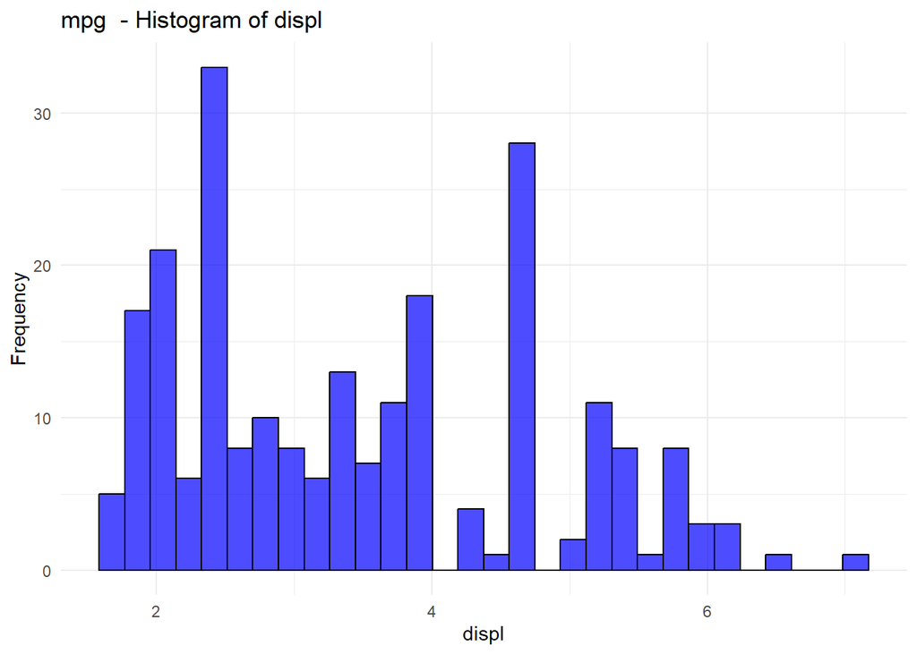

```r
# Call the function
df_plot_by_class(mpg, "numeric")
```

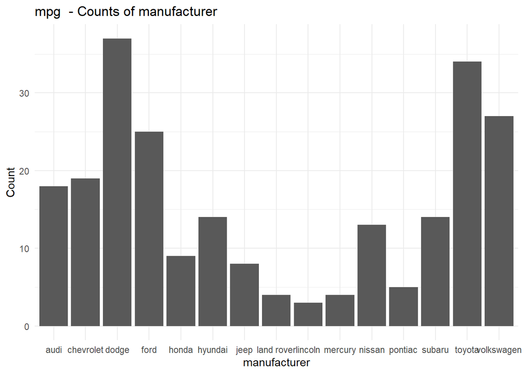

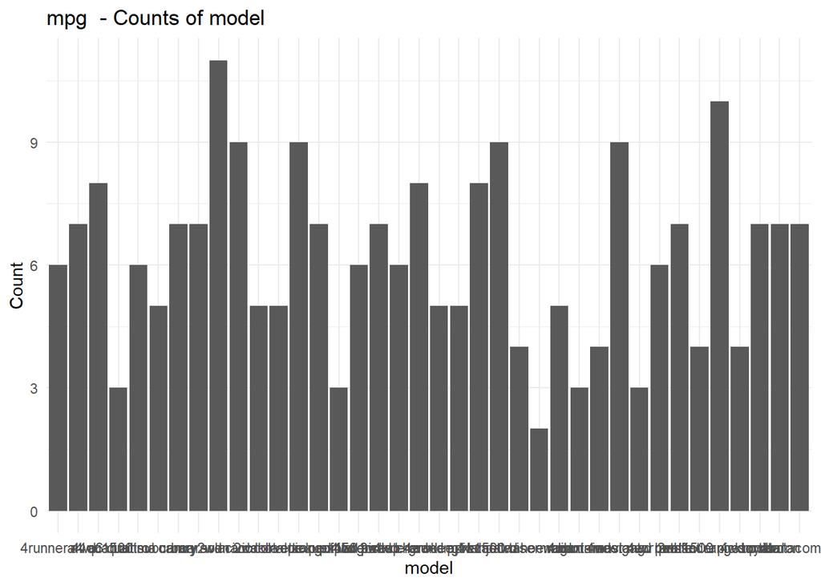

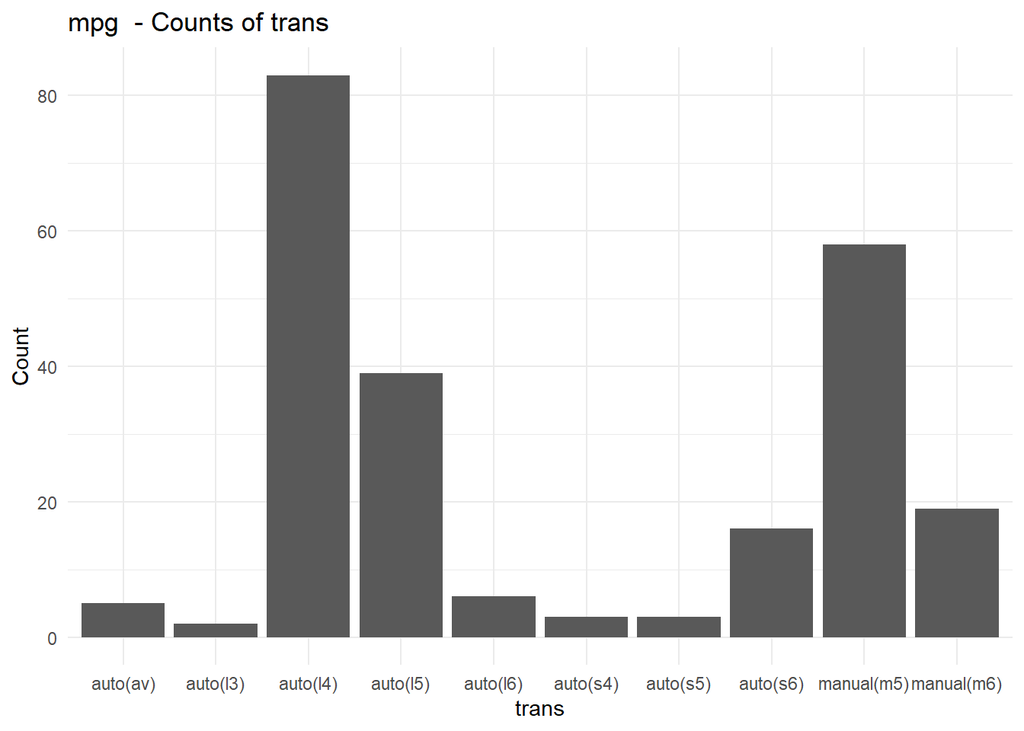

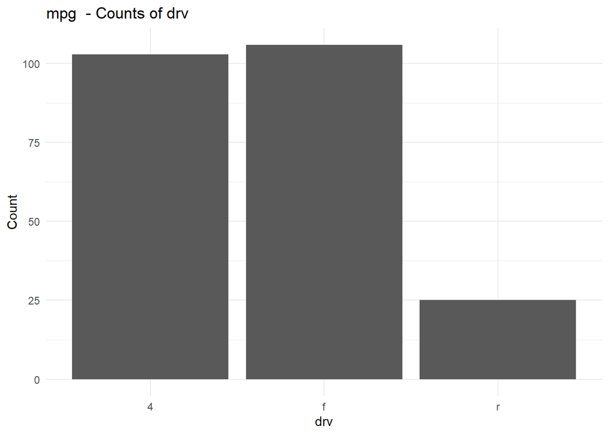

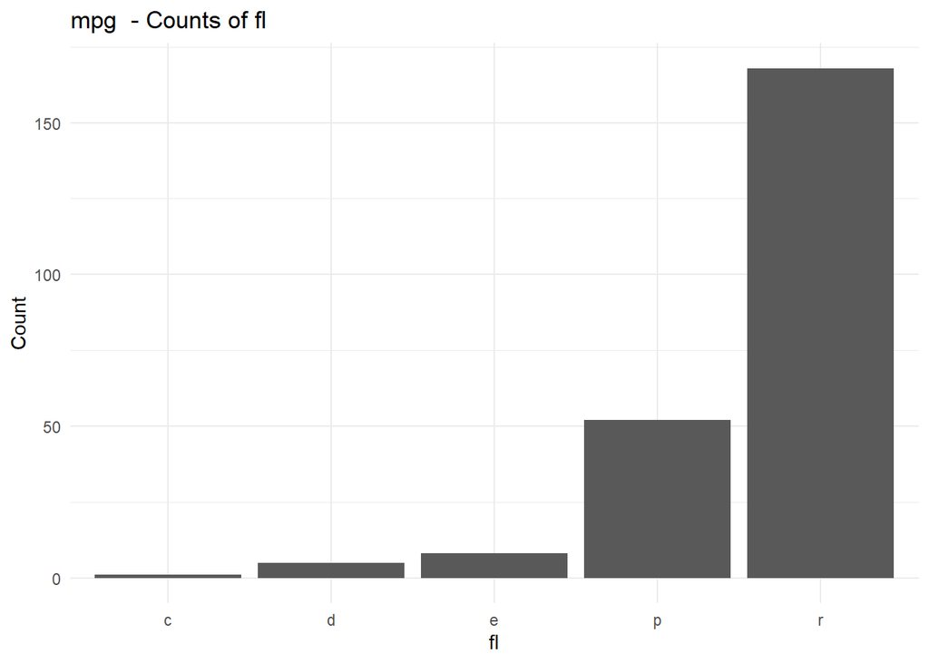

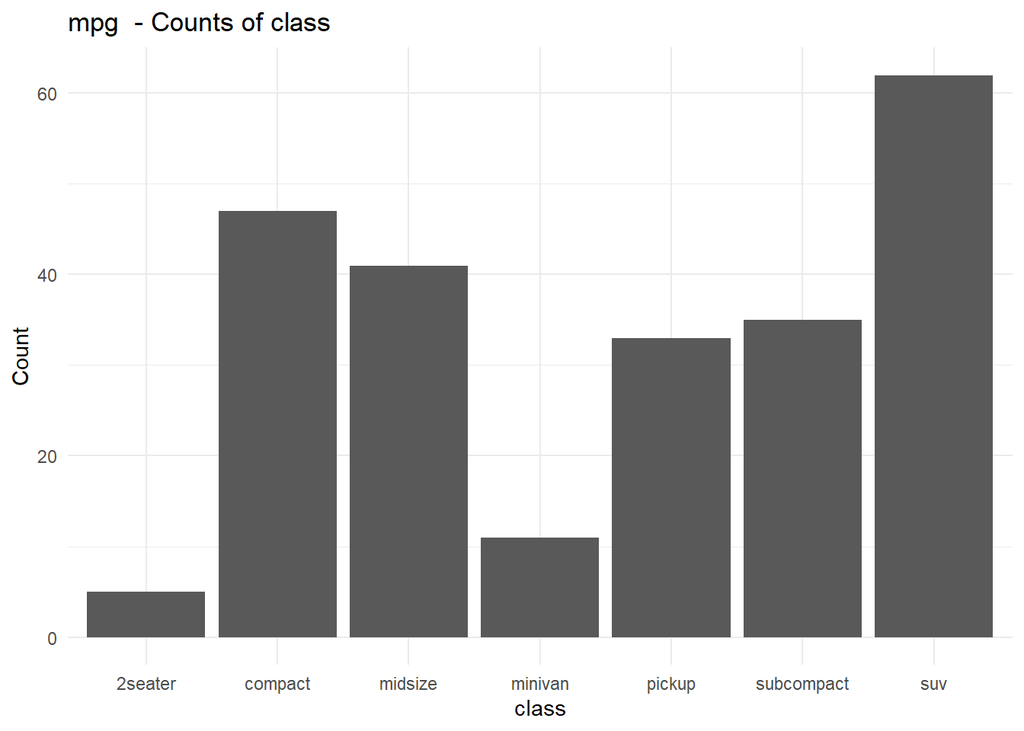

```r
df_plot_by_class(mpg, "character")
```

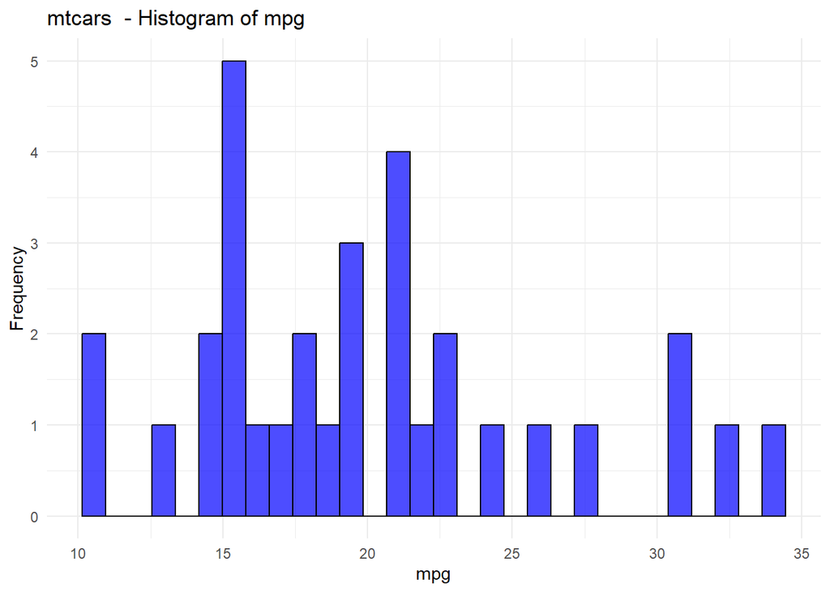

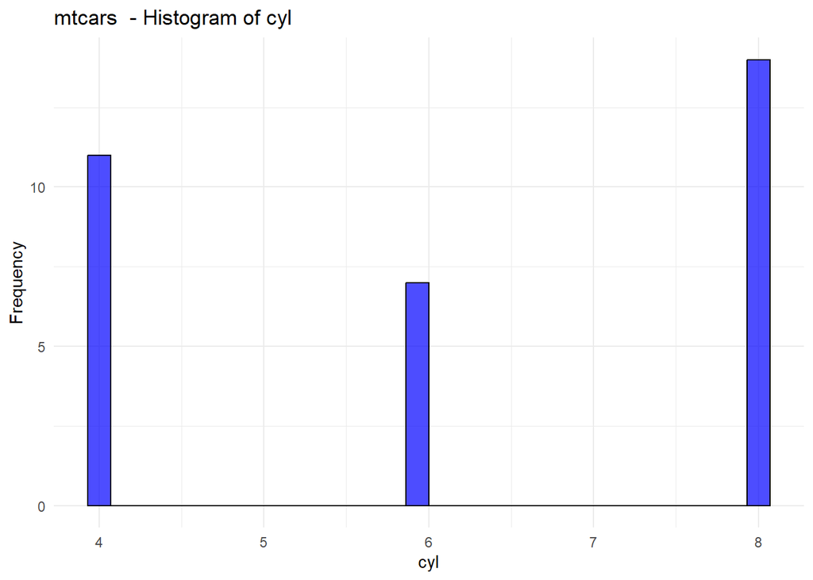

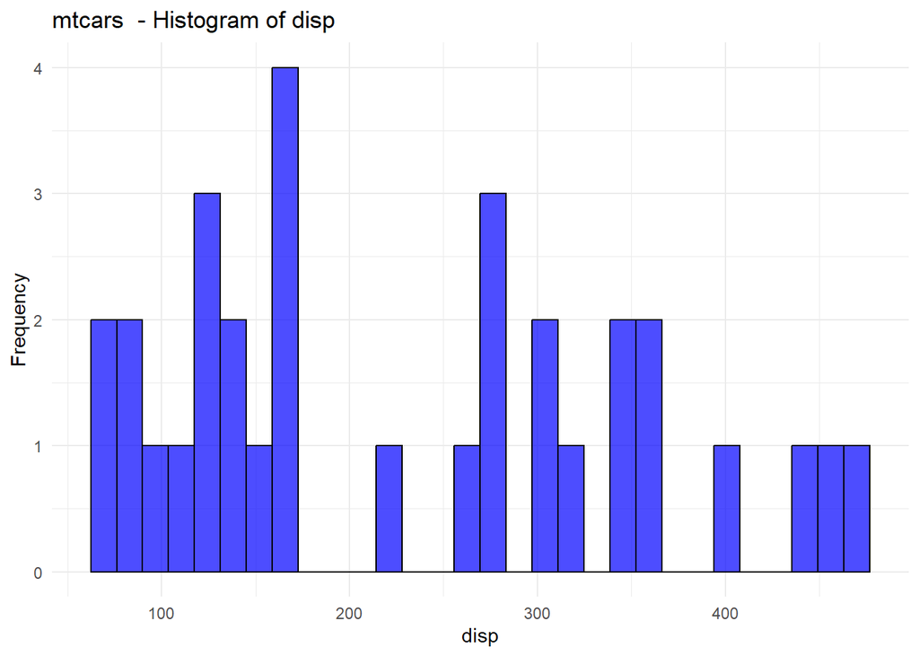

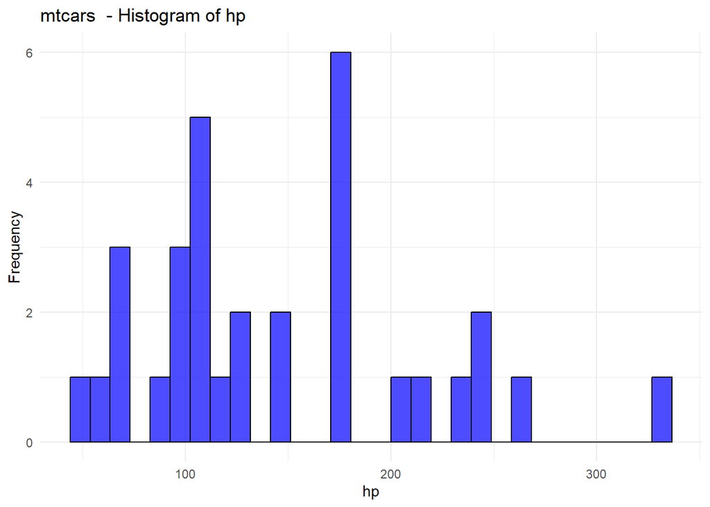

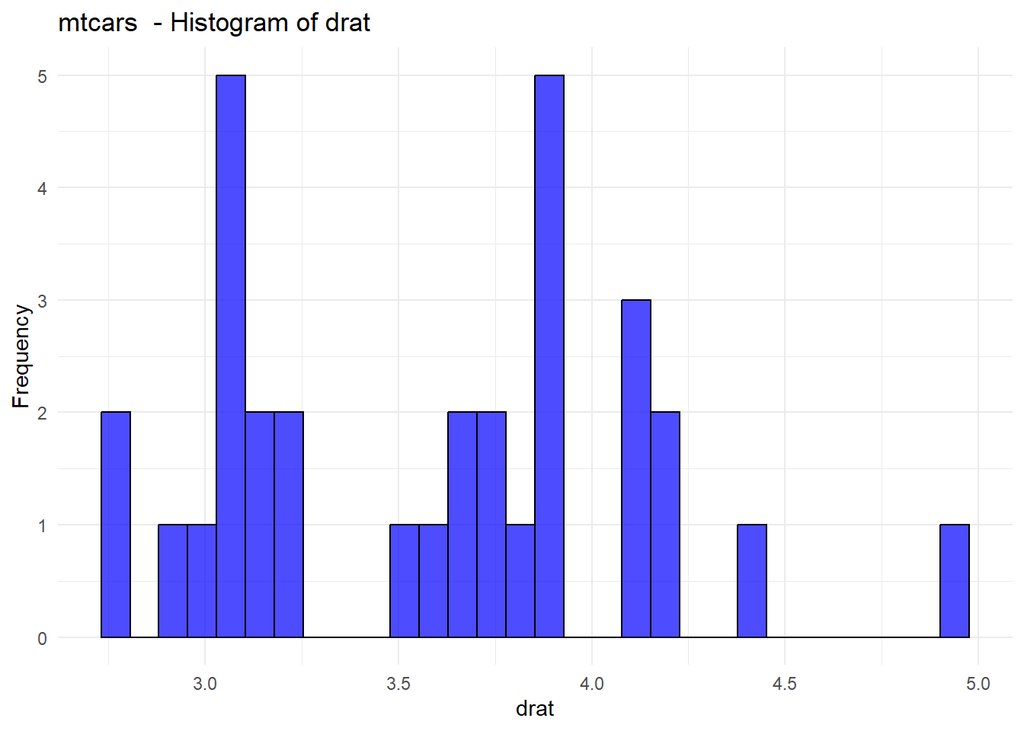

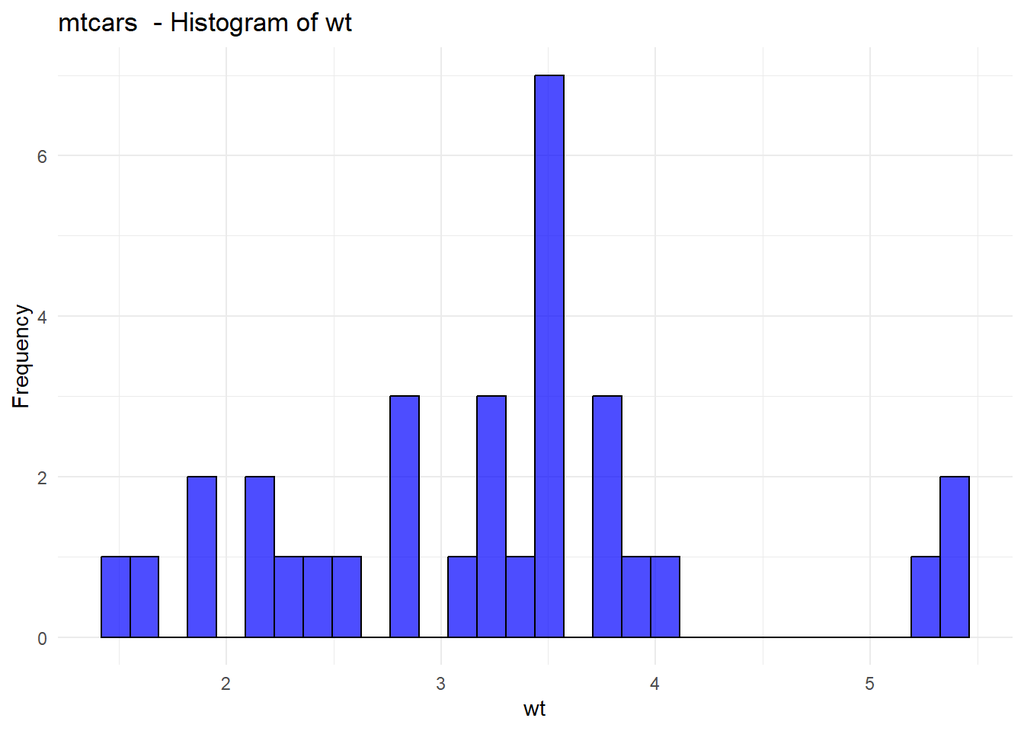

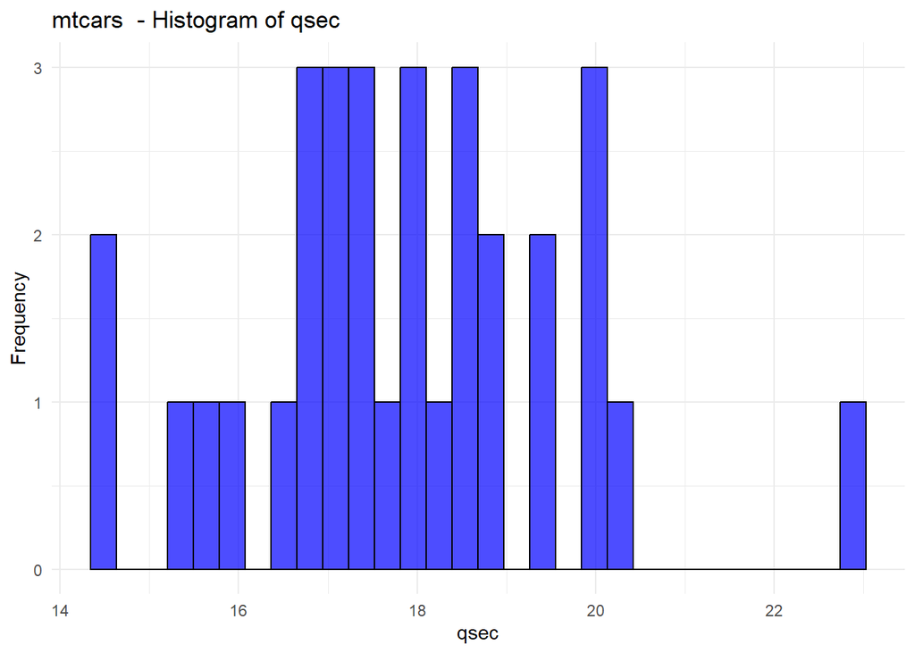

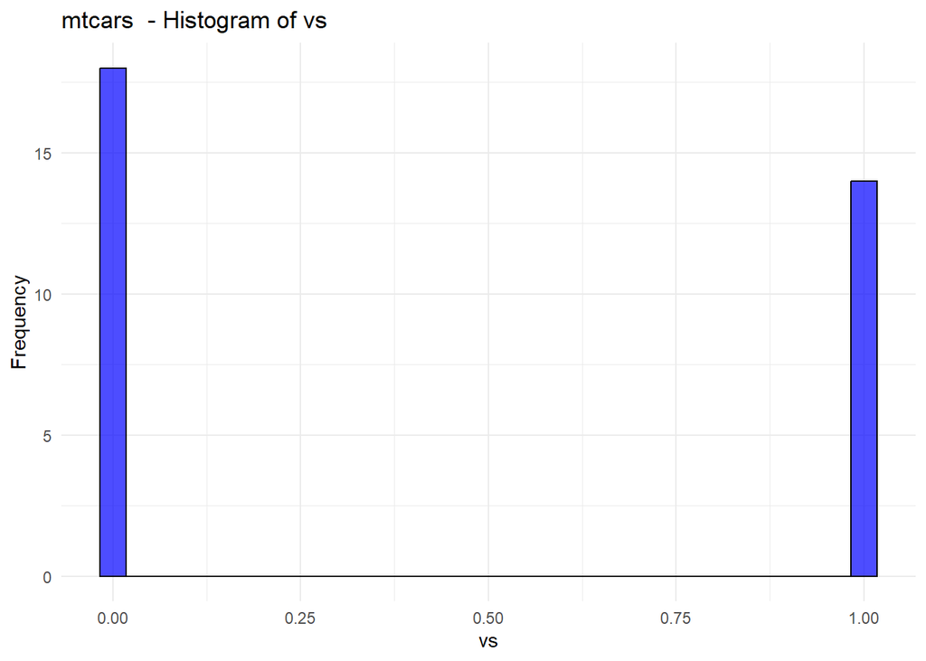

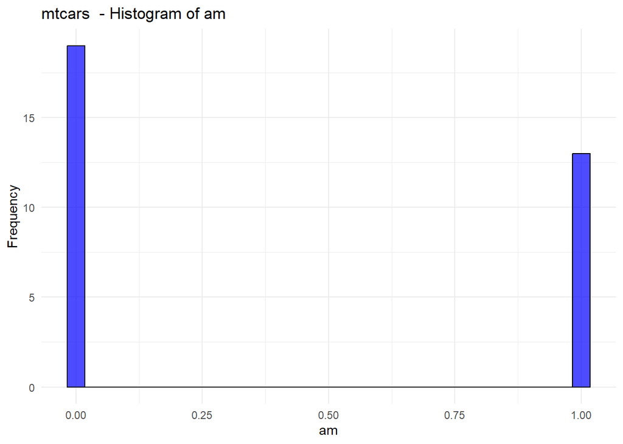

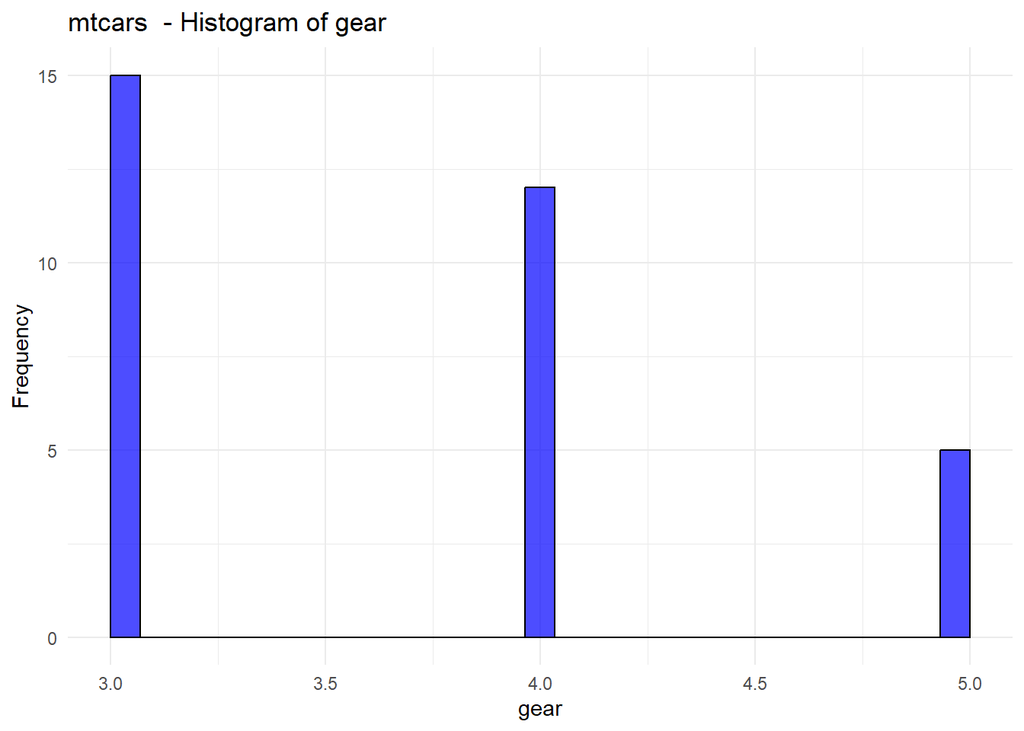

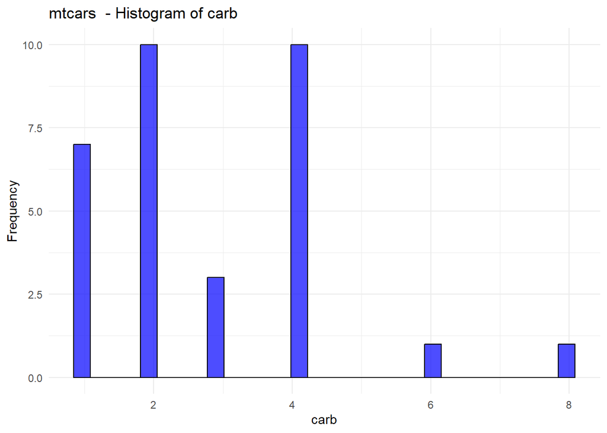

```r
df_plot_by_class(mtcars, "numeric")
```

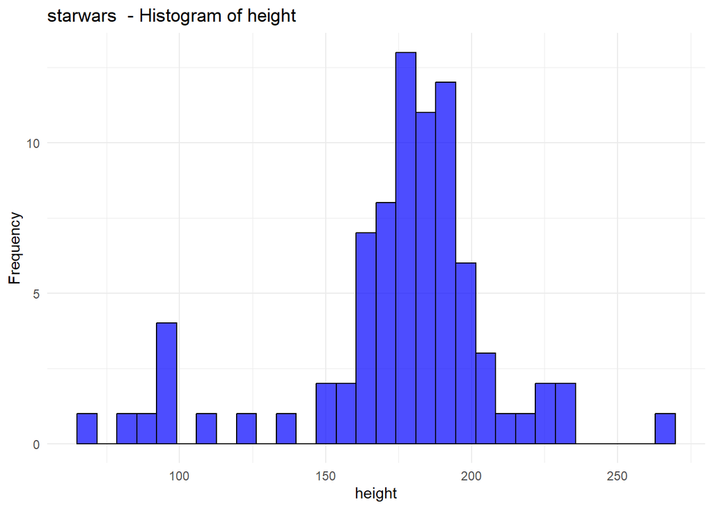

```r
df_plot_by_class(starwars, "integer")
```

## 5 Debugging

Considering the following tools: RStudio “traceback”, Lintr and Styler.

### 5.1 Function: df_attributes.R

Using RStudio “traceback” link to access the function error prompt. See images below.

[figure not shown]

traceback: df_attributes.R

### 5.2 Function: df_plot_by_class.R

Using RStudio “traceback” link to access the function error prompt. See image below.

[figure not shown]

traceback: df_plot_by_class.R

### 5.3 Using Lintr and Styler to comply with {tidyverse} style formats

Both {lintr} and {styler} were used on the functions above to make sure the coding was in comply with the {tidyverse} style recommendation format. Firstly, {lintr} suggested some few editing to the code and after the changes, the code was in comply {lintr}. Following, I ran the {styler} code and Styler still found necessary to automatically changed the code and saved the changes. I would recommend just using Lintr for the future since Styler have a more global set of requirements for coding other than just for R. Both functions in this repo are in perfect agreement with the tidyverse style guide.

See images below for {lintr} and {styler} suggestions and fixes:

df_attributes

#### 5.3.1 Function: df_attributes.R

##### 5.3.1.1 Lintr - Suggestions

[figure not shown]

Lintr: df_attributes

##### 5.3.1.2 Lintr - Cleared

[figure not shown]

Lintr Clear: df_attributes

##### 5.3.1.3 Styler - Suggestions

[figure not shown]

Styler: df_attributes

##### 5.3.1.4 Styler - Cleared

[figure not shown]

Styler Clear: df_attributes

#### 5.3.2 Function: df_plot_by_class.R

##### 5.3.2.1 Lintr - Suggestions

[figure not shown]

Lintr: df_plot_by_class.R

##### 5.3.2.2 Lintr - Clear

[figure not shown]

Lintr Clear: df_plot_by_class.R

##### 5.3.2.3 Styler

[figure not shown]

Styler: df_plot_by_class.R